# Comparing Disney Films

Yuhaniz, Siya, Cole, Jonathan

11/25/2020

## Introduction

Our domain of interest is entertainment so in this report, we’ll be studying a data set comparing all of the movies made by Disney. We are interested in exploring the domain of entertainment because it is a very broad field with lots of available data in part due to the rise of streaming services. This data set includes all Disney movies up to 2016. It can be found [here](https://www.kaggle.com/prateekmaj21/disney-movies?select=disney_movies.csv). We want to study this data to see what types of movies are the most successful in terms of grossing amount. These types of studies help Disney plan future films in terms of the genre, ratings etc. the film should stick to.

## Summary Info

This data displays a few aspects of Disney movies. Some of these include movie release dates, genre, MPAA rating, total gross income and inflation adjusted gross income. In this dataset the highest grossing movie is Snow White and the Seven Dwarfs. Also, the lowest grossing movie would be the movie Zokkomon. With this being said, the most common genre from the data is Comedy and the most common release date year would be 1995. Finally, in this data it displays 579 different movies. Studying these can help Disney better understand their audience and which types of movies they tend to like most.

## Summary Table

This table was created to show the most popular genres of Disney movies.

| Genre | Number of Movies |
| --- | --- |
| Comedy | 182 |
| Adventure | 129 |
| Drama | 114 |
| Action | 40 |
| Thriller/Suspense | 24 |
| Romantic Comedy | 23 |
| Documentary | 16 |
| Musical | 16 |
| Western | 7 |
| Horror | 6 |
| Black Comedy | 3 |
| Concert/Performance | 2 |

The table shows that Comedy, Adventure, and Drama are by far the most common genres of Disney movies in this data set.

## What trends do we see between the yearly gross of Disney movies over time?

This chart was intended to show the relationship between the yearly gross of Disney movies, comparing the inflation adjusted gross and total gross, over time from 1937 to 2016. We made it to see which years made the most movies gross.

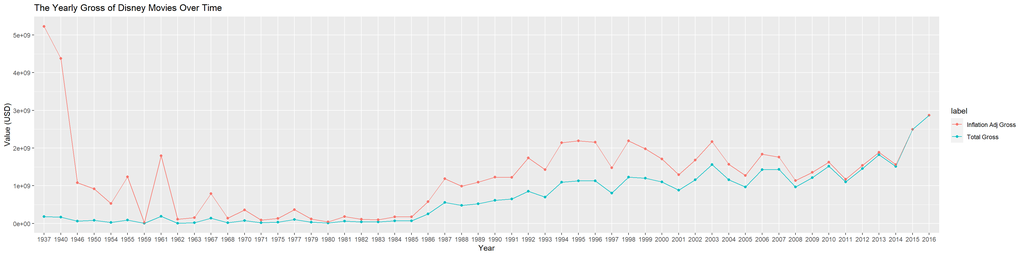

As you can see, the total gross and inflation adjusted gross fluctuates but at and after 2014, there was an increasing trend. Before 2014, the trend of the inflation adjusted gross were all larger than the trend of total gross to account. This is likely to account for the price level changes. But in 2014 and after, the inflation adjusted gross and total gross made the same gross values.

## How does the genre of a Disney movie affect the amount grossed?

This chart plots the relationship between the inflation adjusted gross over all the different genres of movies in the dataset. We made this box plot to see which genres grossed the most money for Disney.

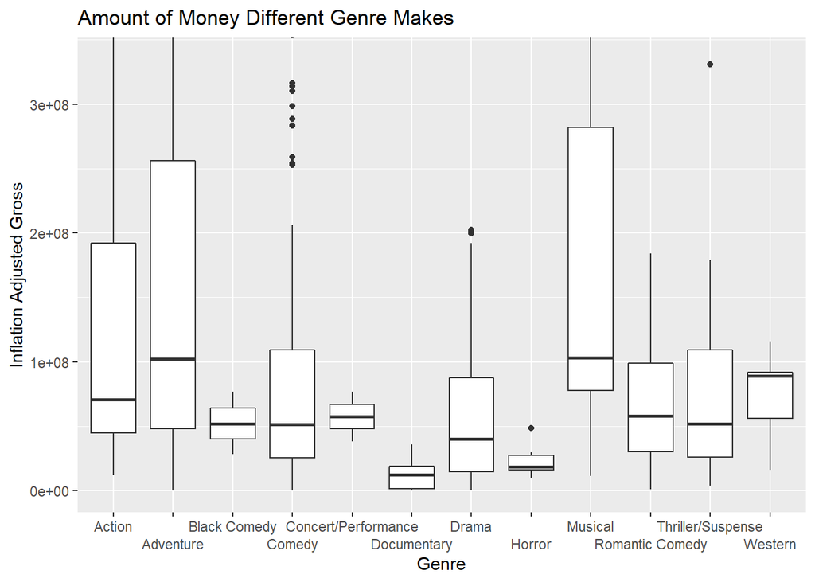

This box plot shows that the Adventure and Musical categories make the most money on average. The genres making the lowest amount of money are Documentary and horror. Musical has an outlier that grossed far more than any other movie. The Y value of the graph plot was limited to make the plot readable.

## What trends do we see in the top 20 highest-grossing Disney films in Disney history?

This bar chart compares the genres and ratings of the 20 highest-grossing films in Disney’s history. We made it to see if there are any trends in which types of movies do the best.

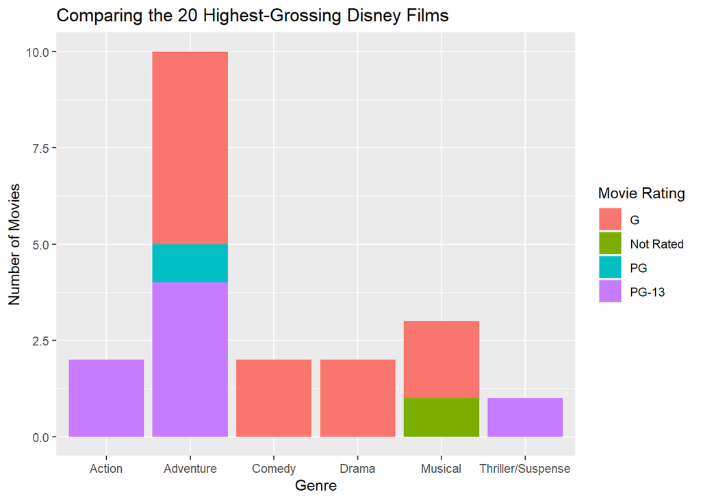

As we can see, the most popular, or highest-grossing, Disney films tend to fall in the adventure genre. These movies are also often rated G. In the earlier chart we did, we found that adventure movies are usually the highest-grossing. I think that from these charts we’ve made, we can infer that Disney has a good understanding of their audience. They clearly know that adventure movies make the most money so they stick to those. This chart can give us more confidence in our prior chart because we once again see that adventure films make a lot of money.